# generate_mesh

This tutorial is part of [FEMlium](http://femlium.github.io/).

[figure not shown]

```python
import os
import urllib
```

```python
import folium
import gmsh
import matplotlib.pyplot as plt
import numpy as np
import numpy.typing as npt
import pyproj
```

```python
import femlium
```

Auxiliary function to get a `folium` `Map` close to Lake Garda.

```python
def get_garda_geo_map(boundary_icons: bool = False) -> folium.Map:
    """Get a map close to Lake Garda, and possibly add some boundary markers."""
    # Add map close to Lake Garda
    geo_map = folium.Map(location=[45.6389113, 10.7521368], zoom_start=10.3)

    # Add markers
    if boundary_icons:
        location_markers = {
            "Sarca": [45.87395405, 10.87087005],
            "Mincio": [45.43259035, 10.7007715]
        }
        location_colors = {
            "Sarca": "red",
            "Mincio": "green"
        }

        for key in location_markers.keys():
            folium.Marker(
                location=location_markers[key],
                tooltip=key,
                icon=folium.Icon(color=location_colors[key])
            ).add_to(geo_map)

    # Return folium map
    return geo_map
```

```python
get_garda_geo_map()
```

Make this Notebook Trusted to load map: File -> Trust Notebook

[interactive chart not shown]

Read the file containing an approximation of the boundary of the lake from csv.

```python
boundary_csv_filename = "garda.csv"
if not os.path.isfile(boundary_csv_filename):
    os.makedirs("data", exist_ok=True)
    boundary_csv_url = (
        "https://raw.githubusercontent.com/FEMlium/FEMlium/main/"
        "tutorials/01_introduction/data/garda.csv")
    with urllib.request.urlopen(boundary_csv_url) as response, \
            open(boundary_csv_filename, "wb") as boundary_csv_file:
        boundary_csv_file.write(response.read())
```

```python
points_and_markers = np.loadtxt("garda.csv", delimiter=",", skiprows=1)
points = points_and_markers[:, 0:2]
vertex_markers = points_and_markers[:, 2].astype(np.int64)
segment_markers = np.array(
    [min(vertex_markers[v], vertex_markers[v + 1]) for v in range(points.shape[0] - 1)], dtype=np.int64)
```

Plot the domain boundary using `matplotlib`.

```
(np.float64(616658.039149),
 np.float64(647061.960851),
 np.float64(5029877.225841),
 np.float64(5085382.774159))
```

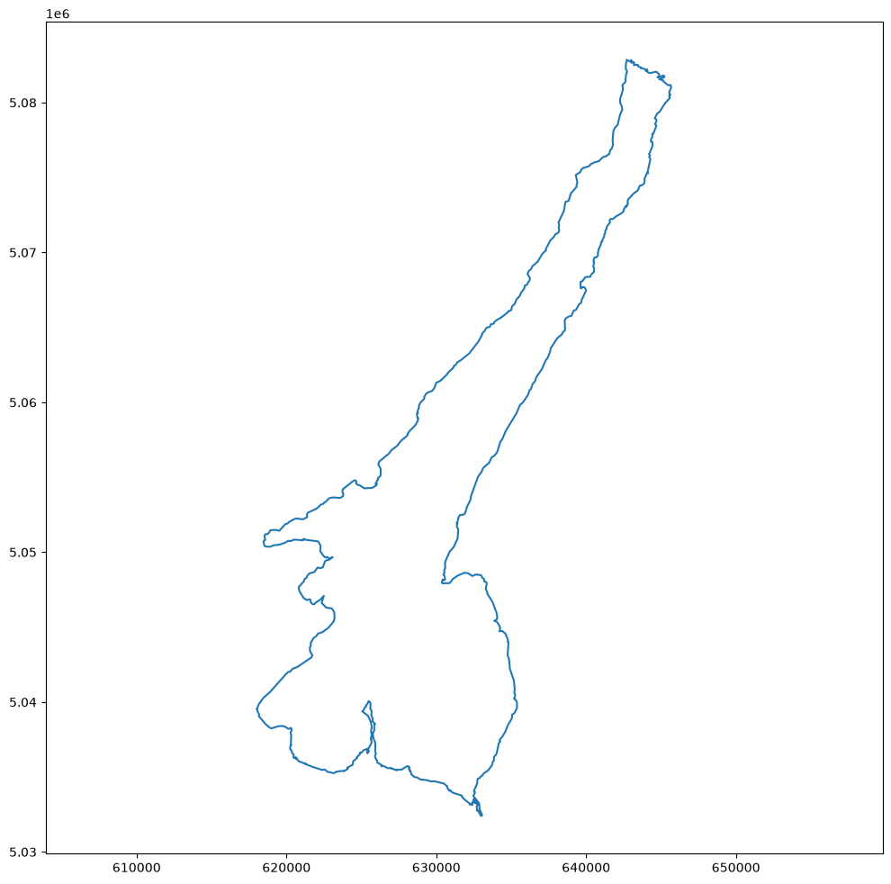

```python
fig = plt.figure(figsize=(12, 12))
fig.gca().plot(points[:, 0], points[:, 1])
fig.gca().axis("equal")
```

Read a further file containing a curve that corresponds to approximately 1000 m from the shoreline.

```python
interface_csv_filename = "garda_interface.csv"
if not os.path.isfile(interface_csv_filename):
    os.makedirs("data", exist_ok=True)
    interface_csv_url = (
        "https://raw.githubusercontent.com/FEMlium/FEMlium/main/"
        "tutorials/01_introduction/data/garda_interface.csv")
    with urllib.request.urlopen(interface_csv_url) as response, \
            open(interface_csv_filename, "wb") as interface_csv_file:
        interface_csv_file.write(response.read())
```

```python
points_inner = np.loadtxt("garda_interface.csv", delimiter=",", skiprows=1)
```

Plot the two curves with `matplotlib`.

```
(np.float64(616658.039149),
 np.float64(647061.960851),
 np.float64(5029877.225841),
 np.float64(5085382.774159))
```

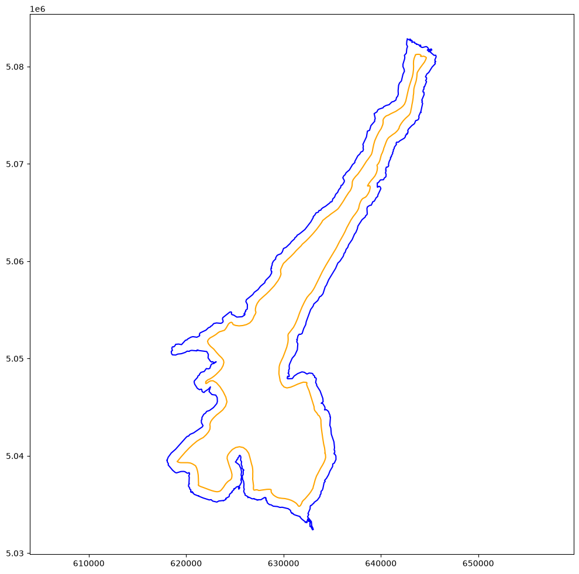

```python
fig = plt.figure(figsize=(12, 12))
fig.gca().plot(points[:, 0], points[:, 1], "blue")
fig.gca().plot(points_inner[:, 0], points_inner[:, 1], "orange")
fig.gca().axis("equal")
```

Define a `pyproj` `Transformer` to map between different reference systems, because the points read from file are stored a $(x, y)$ pairs in the EPSG32632 reference system, while the map produced by `folium` is based on (latitude, longitude) pairs in the EPSG4326 reference system.

```python
transformer = pyproj.Transformer.from_crs("epsg:32632", "epsg:4326", always_xy=True)
```

We define a domain plotter `femlium.DomainPlotter`.

```python
domain_plotter = femlium.DomainPlotter(transformer)
```

We use the `domain_plotter` to draw the boundary of what will be the computational domain on top of the geographic map.

```python
geo_map = get_garda_geo_map()
domain_plotter.add_domain_to(geo_map, points)
geo_map
```

Make this Notebook Trusted to load map: File -> Trust Notebook

[interactive chart not shown]

We may change the color and the weight of the line.

```python
geo_map = get_garda_geo_map()
domain_plotter.add_domain_to(geo_map, points, colors="blue", weights=3)
geo_map
```

Make this Notebook Trusted to load map: File -> Trust Notebook

[interactive chart not shown]

Furthermore, we may set the colors and the weights of the boundary representation to depend on the markers associated to each segment. Such markers are typically used to set boundary labels for boundary conditions.

```python
geo_map = get_garda_geo_map(boundary_icons=True)
colors = {
    0: "blue",
    1: "red",
    2: "green"
}
weights = {
    0: 2,
    1: 5,
    2: 5
}
domain_plotter.add_domain_to(geo_map, points, segment_markers, colors=colors, weights=weights)
geo_map
```

Make this Notebook Trusted to load map: File -> Trust Notebook

[interactive chart not shown]

We may also plot two curves on the same map.

```python
geo_map = get_garda_geo_map()
domain_plotter.add_domain_to(geo_map, points, colors="blue", weights=3)
domain_plotter.add_domain_to(geo_map, points_inner, colors="orange", weights=2)
geo_map
```

Make this Notebook Trusted to load map: File -> Trust Notebook

[interactive chart not shown]

We then use `gmsh` to generate a triangular mesh, and save it to file.

```python
def generate_garda_mesh(
    points: npt.NDArray[np.float64], segment_markers: npt.NDArray[np.int64],
    points_inner: npt.NDArray[np.float64], h: float
) -> None:
    """Generate an unstructured mesh of the Lake."""
    # Initialize gmsh
    gmsh.initialize()
    # Add model
    gmsh.model.add("garda")
    # Add points associated to outer boundary
    num_points = points.shape[0] - 1  # exclude the last point, because it is a copy of the first one
    for p in range(num_points):
        gmsh.model.geo.addPoint(points[p, 0], points[p, 1], 0.0)
    # Add points associted to inner interface
    num_points_inner = points_inner.shape[0] - 1  # exclude the last point, because it is a copy of the first one
    for p in range(num_points_inner):
        gmsh.model.geo.addPoint(points_inner[p, 0], points_inner[p, 1], 0.0)
    # Add segments associated to outer boundary
    lines = list()
    boundary_labels = {
        1: list(),  # shore
        2: list(),  # inflow
        3: list()   # outflow
    }
    for p in range(num_points):
        point_p = p + 1
        if point_p < num_points:
            point_p_next = point_p + 1
        else:
            point_p_next = 1
        segment = gmsh.model.geo.addLine(point_p, point_p_next)
        lines.append(segment)
        label = 1 + segment_markers[p]
        label = round(label)
        boundary_labels[label].append(segment)
    # Add segments associated to inner interface
    lines_inner = list()
    for p in range(num_points_inner):
        point_p = num_points + p + 1
        if point_p < num_points + num_points_inner:
            point_p_next = point_p + 1
        else:
            point_p_next = num_points + 1
        segment = gmsh.model.geo.addLine(point_p, point_p_next)
        lines_inner.append(segment)
    # Add curve loops
    boundary = gmsh.model.geo.addCurveLoop(lines)
    interface = gmsh.model.geo.addCurveLoop(lines_inner)
    # Add surfaces
    near_shore = gmsh.model.geo.addPlaneSurface([boundary, interface])
    far_from_shore = gmsh.model.geo.addPlaneSurface([interface])
    # Synchronize
    gmsh.model.geo.synchronize()
    # Assign boundary labels
    for (label, lines) in boundary_labels.items():
        gmsh.model.addPhysicalGroup(1, lines, label)
    # Assign subdomain labels
    gmsh.model.addPhysicalGroup(2, [near_shore], 1)
    gmsh.model.addPhysicalGroup(2, [far_from_shore], 2)
    # We now define a Distance field, to measure the distance from the boundary
    gmsh.model.mesh.field.add("Distance", 1)
    gmsh.model.mesh.field.setNumbers(1, "PointsList", np.arange(1, num_points + 1))
    gmsh.model.mesh.field.setNumbers(1, "CurvesList", lines)
    gmsh.model.mesh.field.setNumber(1, "NumPointsPerCurve", 1)
    # We then define a Threshold field, which uses the return value of the
    # Distance field 1 in order to define a simple change in element size
    # depending on the computed distances
    #
    # SizeMax -                     /------------------
    #                              /
    #                             /
    #                            /
    # SizeMin -o----------------/
    #          |                |    |
    #        Point         DistMin  DistMax
    gmsh.model.mesh.field.add("Threshold", 2)
    gmsh.model.mesh.field.setNumber(2, "InField", 1)
    gmsh.model.mesh.field.setNumber(2, "SizeMin", h)
    gmsh.model.mesh.field.setNumber(2, "SizeMax", 10 * h)
    gmsh.model.mesh.field.setNumber(2, "DistMin", 600)
    gmsh.model.mesh.field.setNumber(2, "DistMax", 6000)
    # The mesh size should be derived from the second field, i.e. the Distance field
    gmsh.model.mesh.field.setAsBackgroundMesh(2)
    gmsh.option.setNumber("Mesh.MeshSizeExtendFromBoundary", 0)
    gmsh.option.setNumber("Mesh.MeshSizeFromPoints", 0)
    gmsh.option.setNumber("Mesh.MeshSizeFromCurvature", 0)
    # Generate mesh
    gmsh.model.mesh.generate(2)
    # Write out the mesh in gmsh format
    msh_path = "garda.msh"
    if os.path.exists(msh_path):
        os.remove(msh_path)
    gmsh.write(msh_path)
    # Finalize
    gmsh.finalize()
```

```python
generate_garda_mesh(points, segment_markers, points_inner, 300)
```

[output not shown]

[output cut: 1148 more lines]

[output not shown]

The mesh will be read in and displayed in one of the FEM backends available in `femlium`. See the notebooks in the parent folder.